# Lab 3. Variogram and Kriging

Spatial Big Data Analysis with GIS (jaehongjeong@hanyang.ac.kr)

Korean Statistical Society, Winter School, February 24, 2023

This document is based on “Hierarchical Modeling and Analysis for Spatial Data” by Banerjee, Carlin, and Gelfand (https://conservancy.umn.edu/handle/11299/200500).

```r
# Required packages
library(spBayes)
library(classInt)
library(RColorBrewer)
library(MBA)
library(fields)
library(geoR)
library(gstat)
library(sp)
```

# 1 Visualizing Data

We will use WEF forest inventory data from a long-term ecological research site in western Oregon. Diameter at breast height (DBH) and tree height (HT) have been measured for all trees.

We simply use these data to demonstrate some basics of spatial data manipulation, visualization, and exploratory analysis.

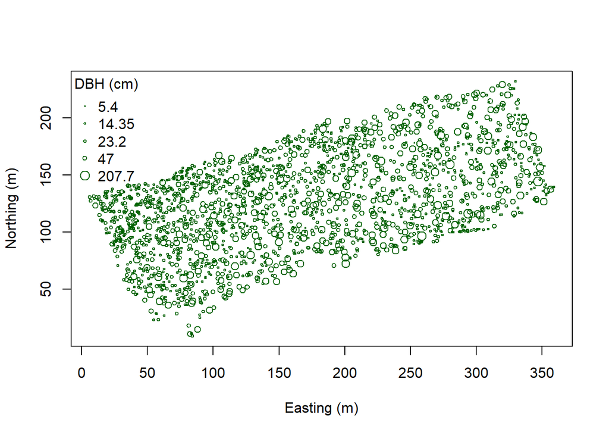

```r
##Visualizing Data
#library(sp)
#library(spBayes)
#library(classInt)
#library(RColorBrewer)

#load data
data(WEF.dat)

#remove possible NaNs
WEF.dat <- WEF.dat[!apply(WEF.dat[,c("East_m","North_m","DBH_cm","Tree_height_m","ELEV_m")],1,function(x){any(is.na(x))}),]
DBH <- WEF.dat$DBH_cm
HT <- WEF.dat$Tree_height_m
coords <- as.matrix(WEF.dat[,c("East_m","North_m")])

plot(coords,pch=1,cex=sqrt(DBH)/10,col="darkgreen", xlab="Easting (m)", ylab="Northing (m)")
leg.vals <- round(quantile(DBH),10)
legend("topleft",pch=1,legend=leg.vals,col="darkgreen", pt.cex=sqrt(leg.vals)/10,bty="n",title="DBH (cm)")
```

To further explore spatial pattern ${\tt DBH}$, it is often useful to use a color gradient or ramp to construct the pallet.

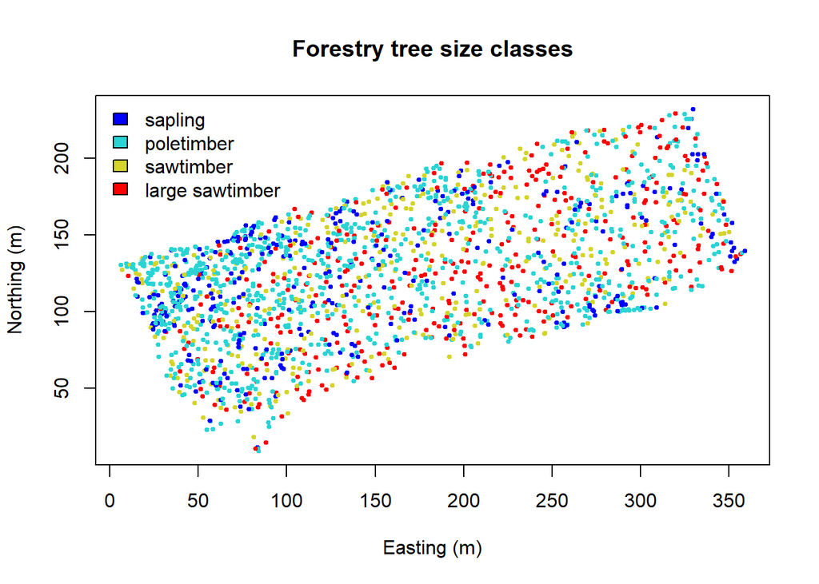

```r
#Plot by tree species
col.br <- colorRampPalette(c("blue","cyan","yellow","red"))
col.pal <- col.br(5)
fixed  <- classIntervals(DBH,n=4,style="fixed", fixedBreaks=c(0,12.7,30.48,60,max(DBH)+1))

fixed.col<-findColours(fixed,col.pal)

plot(coords, col=fixed.col, pch=19, cex=0.5, main="Forestry tree size classes", xlab="Easting (m)", ylab = "Northing (m)")
legend("topleft",fill=attr(fixed.col,"palette"), legend=c("sapling","poletimber","sawtimber","large sawtimber"), bty="n", text.width=2)
```

If the data observations are well distributed over the domain, spatial pattern can often be detected by estimating a continuous surface using an interpolation function. ${\tt MBA}$ provides efficient interpolation of large data sets with multilevel B-splines.

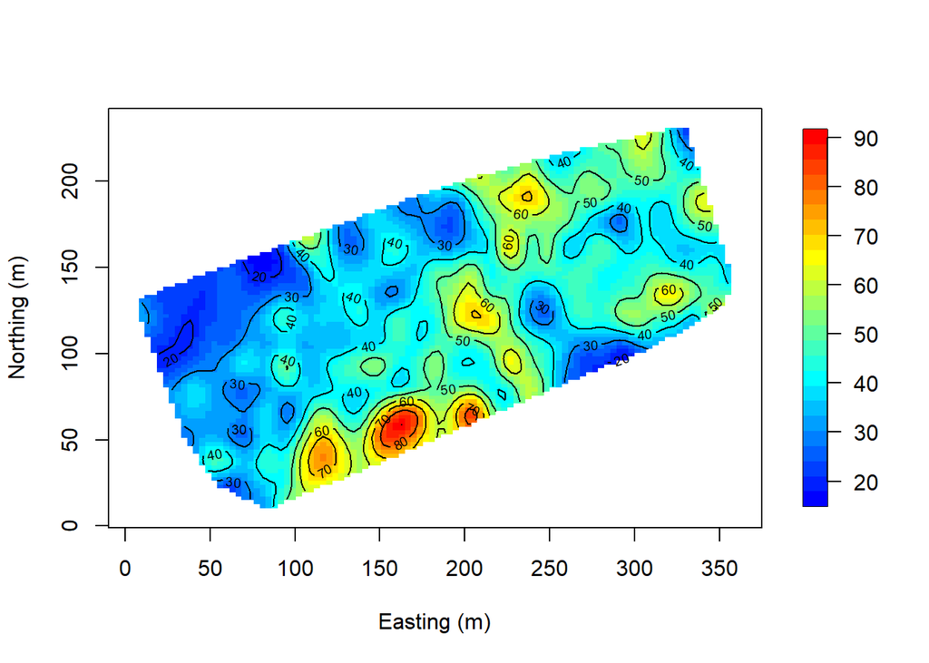

```r
#surface and contour plots
#library(MBA)
#library(fields)

x.res<-100
y.res<-100

surf <- mba.surf(cbind(coords,DBH), no.X=x.res, no.Y=y.res, h=5, m=2, extend=FALSE)$xyz.est

image.plot(surf,xaxs="r",yaxs="r",xlab="Easting (m)",ylab="Northing (m)",col=col.br(25))

contour(surf,add=T)
```

# 2 Variogram

```r
#variogram plots
#library(geoR)
max.dist <- 0.25*max(iDist(coords))

bins <- 50

vario.DBH <- variog(coords=coords, data=DBH, uvec=(seq(0,max.dist,length=bins)))
```

```
## variog: computing omnidirectional variogram
```

```r
fit.DB <- variofit(vario.DBH, ini.cov.pars=c(600,200/-log(0.05)), cov.model="exponential", minimisation.function="nls", weights="equal")
```

```
## variofit: covariance model used is exponential
## variofit: weights used: equal
## variofit: minimisation function used: nls
```

```r
summary(fit.DB)
```

```
## $pmethod
## [1] "OLS (ordinary least squares)"
##
## $cov.model
## [1] "exponential"
##
## $spatial.component
##  sigmasq      phi
## 455.9963  12.7095
##
## $spatial.component.extra
## kappa
##   0.5
##
## $nugget.component
##    tausq
## 542.2718
##
## $fix.nugget
## [1] FALSE
##
## $fix.kappa
## [1] TRUE
##
## $practicalRange
## [1] 38.07425
##
## $sum.of.squares
##    value
## 151227.4
##
## $estimated.pars
##    tausq  sigmasq      phi
## 542.2718 455.9963  12.7095
##
## $weights
## [1] "equal"
##
## $call
## variofit(vario = vario.DBH, ini.cov.pars = c(600, 200/-log(0.05)),
##     cov.model = "exponential", weights = "equal", minimisation.function = "nls")
##
## attr(,"class")
## [1] "summary.variomodel"
```

```r
lm.DBH <- lm(DBH~Species, data = WEF.dat)
summary(lm.DBH)
```

```
##
## Call:
## lm(formula = DBH ~ Species, data = WEF.dat)
##
## Residuals:
##     Min      1Q  Median      3Q     Max
## -78.423  -9.969  -3.561  10.924 118.277
##
## Coefficients:
##             Estimate Std. Error t value Pr(>|t|)
## (Intercept)   89.423      1.303  68.629   <2e-16 ***
## SpeciesGF    -51.598      4.133 -12.483   <2e-16 ***
## SpeciesNF     -5.873     15.744  -0.373    0.709
## SpeciesSF    -68.347      1.461 -46.784   <2e-16 ***
## SpeciesWH    -48.062      1.636 -29.377   <2e-16 ***
## ---
## Signif. codes:  0 '***' 0.001 '**' 0.01 '*' 0.05 '.' 0.1 ' ' 1
##
## Residual standard error: 22.19 on 1950 degrees of freedom
## Multiple R-squared:  0.5332, Adjusted R-squared:  0.5323
## F-statistic: 556.9 on 4 and 1950 DF,  p-value: < 2.2e-16
```

```r
DBH.resid <- resid(lm.DBH)

vario.DBH.resid <- variog(coords=coords, data = DBH.resid, uvec=(seq(0,max.dist,length=bins)))
```

```
## variog: computing omnidirectional variogram
```

```r
fit.DB.resid <- variofit(vario.DBH.resid, ini.cov.pars=c(300,200/-log(0.05)), cov.model = "exponential", minimisation.function="nls", weights="equal")
```

```
## variofit: covariance model used is exponential
## variofit: weights used: equal
## variofit: minimisation function used: nls
```

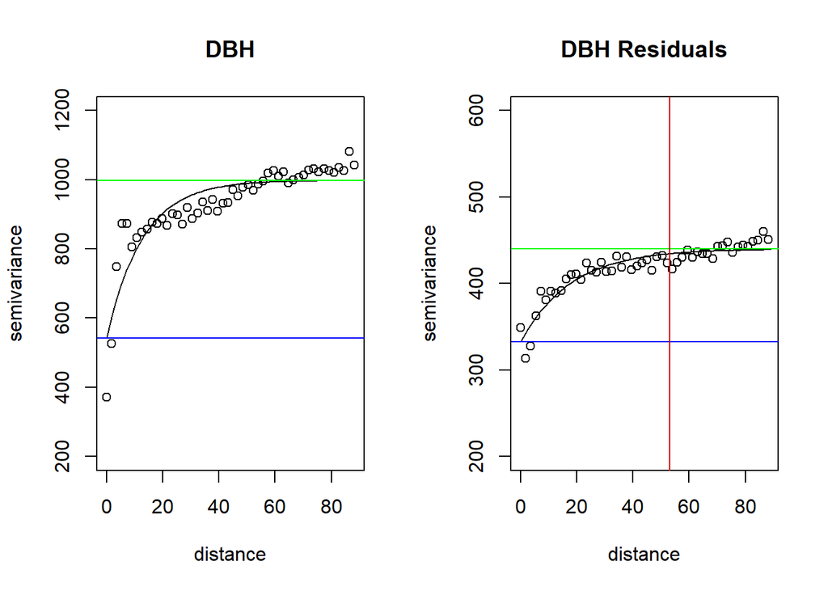

```r
par(mfrow=c(1,2))
plot(vario.DBH,ylim=c(200,1200),main="DBH")
lines(fit.DB)
abline(h=fit.DB$nugget, col="blue")
abline(h=fit.DB$cov.pars[1] + fit.DB$nugget, col="green")

plot(vario.DBH.resid,ylim=c(200,600),main="DBH Residuals")
lines(fit.DB.resid)
abline(h=fit.DB.resid$nugget, col="blue")
abline(h=fit.DB.resid$cov.pars[1] + fit.DB.resid$nugget, col="green")
abline(v=-log(0.05)*fit.DB.resid$cov.pars[2],col="red3")
```

We can check for possible anisotropic patterns in spatial dependence. The ${\tt gstat}$ package offers a ${\tt variogram}$ function that can be regarded as more versatile than its ${\tt geoR}$ counterpart in that it allows us to specify a linear regression model ${\it within}$ it and conduct the variogram analysis on the residuals without having to explicitly collect the residuals.

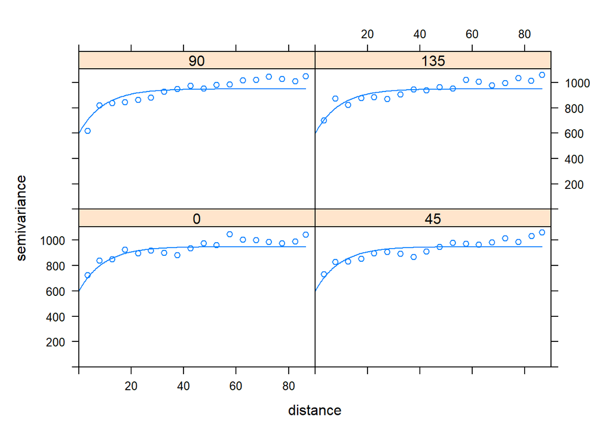

```r
#library(gstat)
ELEV_m <- WEF.dat$ELEV_m
dats = matrix(0,1955,2)
dats[,1] = DBH
dats[,2] = ELEV_m
sp.dat <- SpatialPointsDataFrame(as.data.frame(coords), as.data.frame(dats))
vario.DBH <- variogram(DBH~ELEV_m, data=sp.dat, cutoff=max.dist,width=5,alpha = (0:3)*45)
fit.DBH <- fit.variogram(vario.DBH,vgm(1000,"Exp",200/-log(0.05),600))
print(plot(vario.DBH,fit.DBH))
```

# 3 Kriging

We will perform ordinary Kriging based on previous variogram fitting using residuals. We can obtain Kriging predicted values and variances coupled with ${\tt krige.conv}$ function. Kriging surface maps for both can be obtained using various functions, e.g., ${\tt mba.surf}$ (based on multilevel B-spline).

```r
####kriging
sp.dat2 <- as.geodata(cbind(DBH.resid,coords))
loci <- expand.grid(seq(min(coords[,1]),max(coords[,1]),l=40), seq(min(coords[,2]),max(coords[,2]),l=40))

krigpreds <- krige.conv(sp.dat2, coords=coords, data=DBH.resid, location=loci, krige=krige.control(cov.pars=c(fit.DB.resid$cov.pars[1], fit.DB.resid$cov.pars[2])))
```

```
## krige.conv: model with constant mean
## krige.conv: Kriging performed using global neighbourhood
```

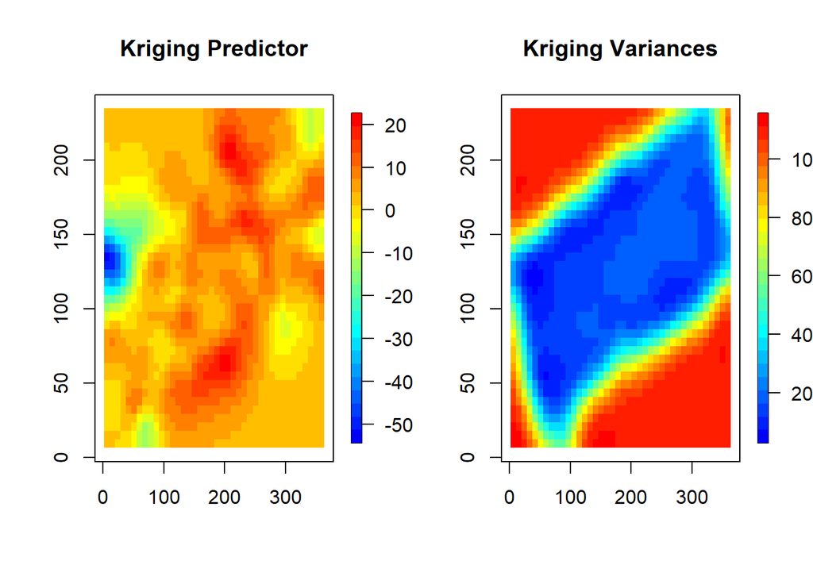

```r
# Surface approximation using multilevel B-splines
surf1 <- mba.surf(cbind(loci,krigpreds$predict),no.X=40,no.Y=40,h=5,m=1,extend=FALSE)$xyz.est
surf2 <- mba.surf(cbind(loci,krigpreds$krige.var),no.X=40,no.Y=40,h=5,m=1,extend=FALSE)$xyz.est

par(mfrow=c(1,2))
image.plot(surf1,xaxs="r",yaxs="r",xlab=" ",ylab=" ",col=col.br(25),main="Kriging Predictor")
image.plot(surf2,xaxs="r",yaxs="r",xlab=" ",ylab=" ",col=col.br(25),main="Kriging Variances")
```

On the other hand, we can also perform Kriging based on the covariance model. Since it takes some time, we only use sub-sample of size 150. We first fit a Matern covariance model and then create Kriging surface maps on a grid using ${\tt predictSurface}$ and ${\tt predictSurfaceSE}$ functions (thin plate spline estimates).

```r
# Kriging with a stationary Matern covariance function using sub-samples
set.seed(20230224)
sample.idx <- sample(1:length(DBH.resid),150,replace=FALSE)
fit <- Krig(coords[sample.idx,], DBH.resid[sample.idx],
Covariance="Matern", aRange=10, smoothness=1.0)
summary(fit)
```

```
## CALL:
## Krig(x = coords[sample.idx, ], Y = DBH.resid[sample.idx], Covariance = "Matern",
##     aRange = 10, smoothness = 1)
##
##  Number of Observations:                150
##  Number of unique points:               150
##  Number of parameters in the null space 3
##  Parameters for fixed spatial drift     3
##  Effective degrees of freedom:          25.5
##  Residual degrees of freedom:           124.5
##  MLE tau                                17.28
##  GCV tau                                17.45
##  MLE sigma                              71.8
##  Scale passed for covariance (sigma)    <NA>
##  Scale passed for nugget (tau^2)        <NA>
##  Smoothing parameter lambda             4.158
##
## Residual Summary:
##      min    1st Q   median    3rd Q      max
## -54.0300  -7.8910  -0.4093   8.2790  42.8800
##
## Covariance Model: stationary.cov
##   Covariance function is  Matern
##   Names of non-default covariance arguments:
##        Covariance, aRange, smoothness
##
## DETAILS ON SMOOTHING PARAMETER:
##  Method used:   REML    Cost:  1
##    lambda       trA       GCV   GCV.one GCV.model    tauHat
##     4.158    25.532   367.161   367.161        NA    17.455
##
##  Summary of all estimates found for lambda
##            lambda   trA   GCV tauHat -lnLike Prof converge
## GCV         4.854 23.11 367.0  17.62        642.3        4
## GCV.model      NA    NA    NA     NA           NA       NA
## GCV.one     4.854 23.11 367.0  17.62           NA        4
## RMSE           NA    NA    NA     NA           NA       NA
## pure error     NA    NA    NA     NA           NA       NA
## REML        4.158 25.53 367.2  17.45        642.3        3
```

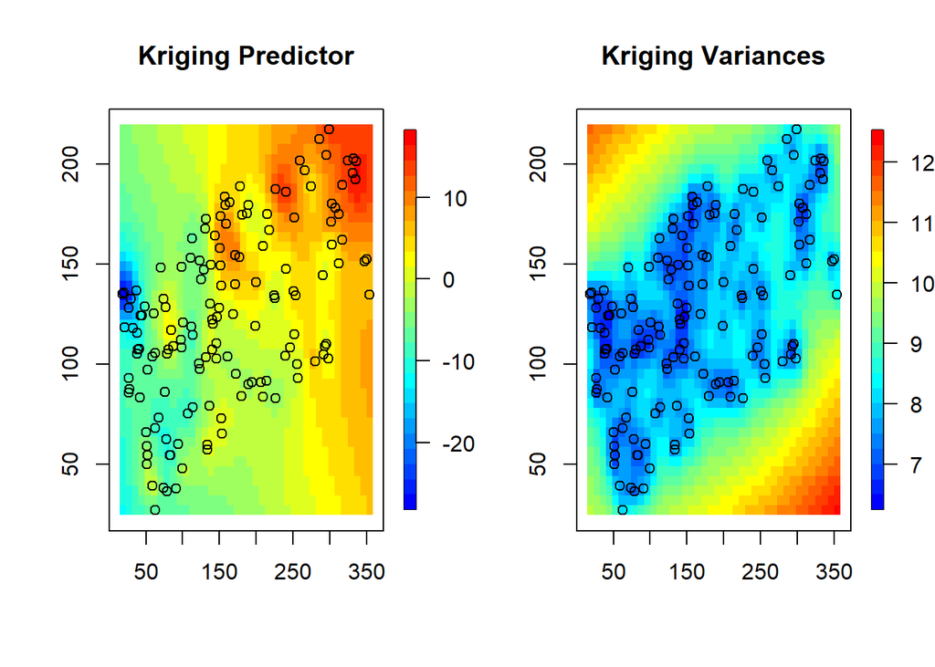

```r
# prediction and standard errors on a grid
out <- predictSurface(fit,extrap=TRUE,nx=40,ny=40)
out.p <- predictSurfaceSE(fit,extrap=TRUE,nx=40,ny=40) # this takes some time!

par(mfrow=c(1,2))
image.plot(out,xaxs="r",yaxs="r",xlab=" ",ylab=" ",col=col.br(25),main="Kriging Predictor")
points(fit$x)
image.plot(out.p,xaxs="r",yaxs="r",xlab=" ",ylab=" ",col=col.br(25),main="Kriging Variances")
points(fit$x)
```

```r
#par(mfrow=c(1,2))
#surface(out, type="C")
#points(fit$x)
#surface(out.p, type="C")
#points(fit$x)
```

Note that Kriging variances between the two models are quite different, so one may think that the covariance model works better than the variogram model. However, this is not true because they considered different sample sizes and not the same dependence structures. Moreover, we applied different approaches to creating Kriging surface maps.